# stateFarmEx5_modelTuning

```python
# Find out if any feature (or label) is correlated with another feature (or label)
corr = train.corr()
print(corr)
```

```
           x0        x1        x2        x3        x4        x5        x6  \
x0   1.000000 -0.216073 -0.159510 -0.144056 -0.258273 -0.081931  0.002036
x1  -0.216073  1.000000 -0.026633 -0.033854 -0.019486  0.085917 -0.002607
x2  -0.159510 -0.026633  1.000000 -0.090230 -0.063998  0.004522  0.001912
x3  -0.144056 -0.033854 -0.090230  1.000000  0.012888 -0.011239 -0.004446
x4  -0.258273 -0.019486 -0.063998  0.012888  1.000000  0.004014 -0.002578
x5  -0.081931  0.085917  0.004522 -0.011239  0.004014  1.000000  0.005042
x6   0.002036 -0.002607  0.001912 -0.004446 -0.002578  0.005042  1.000000
x7  -0.003344  0.010310 -0.000065 -0.002610 -0.001084  0.002391  0.003435
x8   0.111913 -0.119408 -0.003374 -0.023751  0.069873 -0.050108  0.005704
x9  -0.011634  0.006514  0.000018  0.000128  0.005170  0.004125 -0.003781
x10  0.248887  0.019201 -0.004942 -0.054896 -0.086182 -0.087534 -0.000473
x11 -0.007233  0.007193 -0.000847  0.001774  0.001335 -0.001803 -0.004169
x12  0.009515  0.089568  0.054249 -0.097220  0.031588 -0.016633 -0.005284
x13  0.002262  0.003556  0.008722 -0.002843 -0.003953  0.003328 -0.006150
x14 -0.001307 -0.007573 -0.006954  0.001143 -0.000196  0.003541  0.001205
x15 -0.002391  0.001405 -0.000952  0.003650 -0.000141  0.000191 -0.003825
x16 -0.007201  0.000170 -0.001728 -0.008373  0.005521 -0.010195 -0.004522
x17 -0.006262 -0.002565  0.000631  0.002881 -0.003395  0.006324  0.009225
x18 -0.006709 -0.038233 -0.022717 -0.045150  0.002788  0.049030  0.003478
x19 -0.110670  0.008551 -0.126112  0.081075  0.061130 -0.021846  0.003284
x20 -0.217460  0.062810  0.028760  0.051539 -0.047762  0.031881  0.000533
x21  0.352400  0.103305 -0.027318 -0.042671  0.028991  0.059009 -0.006816
x22 -0.106419  0.117072  0.031479 -0.015829 -0.091564  0.051823 -0.005058
x23  0.000502 -0.007649  0.006188 -0.000687  0.000897 -0.002460 -0.003932
x24  0.006813  0.000876 -0.004554  0.005004 -0.002786 -0.006085 -0.001938
x25  0.078838  0.014804 -0.036064 -0.101005  0.056818 -0.143932 -0.000873
x26 -0.007596  0.008252 -0.004114  0.004668  0.001220 -0.001219 -0.010714
x27  0.183256 -0.009954  0.077941 -0.039948  0.066166  0.027036 -0.006123
x28 -0.000431 -0.000201 -0.001649  0.003826  0.001957  0.005307 -0.000522
x29 -0.000220 -0.005893  0.007783 -0.004340  0.005548  0.002714 -0.002999
x30  0.001265 -0.006609 -0.002950  0.006192  0.003675 -0.000784 -0.003320
x31 -0.001644  0.011464  0.011411  0.008693 -0.008022  0.001239  0.009479
x32  0.005350  0.001824 -0.000762  0.001264 -0.006214  0.001288 -0.004967
x33 -0.143008 -0.025434 -0.056405  0.113428  0.165344 -0.052370 -0.003949
x34 -0.002575 -0.001929  0.009425 -0.006558  0.001316  0.000374  0.002927
x35 -0.149352 -0.011893  0.049650  0.033533 -0.010647 -0.069393  0.002096
x36 -0.008478  0.004616  0.004255  0.006409 -0.000492  0.007893 -0.008104
x37 -0.195180 -0.120350  0.043558  0.104067  0.032808  0.232905 -0.005590
x38  0.005544 -0.000381  0.002337 -0.000072  0.003651  0.003133 -0.004314
```

[output cut: 1489 more lines]

```
x86  0.007886  0.007404 -0.002762
x87 -0.000643  0.000333 -0.000363
x88 -0.000903  0.000714  0.006995
x89  0.004077 -0.003356 -0.002694
x90 -0.001674 -0.122160 -0.001556
x91 -0.001100 -0.006776 -0.001588
x92 -0.003124 -0.004806 -0.007164
x93 -0.008153 -0.004271 -0.007497
x94  0.003225 -0.007866  0.003524
x95 -0.004871 -0.007951 -0.005196
x96 -0.009041  0.139026 -0.091520
x97  0.004054  0.048822  0.187624
x98  1.000000 -0.000126  0.005965
x99 -0.000126  1.000000  0.099602
y    0.005965  0.099602  1.000000
```

```python
# Find correlation coefficient of label y with features (independent variables).
print(corr['y'].sort_values(ascending=False))
```

```
y      1.000000
x97    0.187624
x58    0.185919
x1     0.104977
x99    0.099602
x33    0.096974
x79    0.096403
x69    0.094581
x78    0.092398
x63    0.092179
x40    0.091926
x83    0.091236
x73    0.090140
x2     0.089536
x72    0.089135
x85    0.087130
x51    0.086283
x35    0.062690
x44    0.053392
x53    0.014120
x68    0.013407
x38    0.013329
x74    0.009826
x9     0.008672
x88    0.006995
x7     0.006486
x46    0.006101
x98    0.005965
x13    0.005893
x65    0.005807
x23    0.005371
x18    0.005033
x54    0.005017
x52    0.004751
x25    0.004226
x62    0.004092
x94    0.003524
x36    0.003482
x57    0.002828
x64    0.002107
```

[output cut: 47 more lines]

```
x10   -0.082334
x5    -0.086955
x56   -0.090172
x45   -0.091122
x50   -0.091360
x96   -0.091520
x21   -0.092107
x3    -0.093682
x66   -0.096049
x22   -0.097636
x70   -0.106798
x41   -0.177506
x37   -0.197748
x75   -0.204686
Name: y, dtype: float64
```

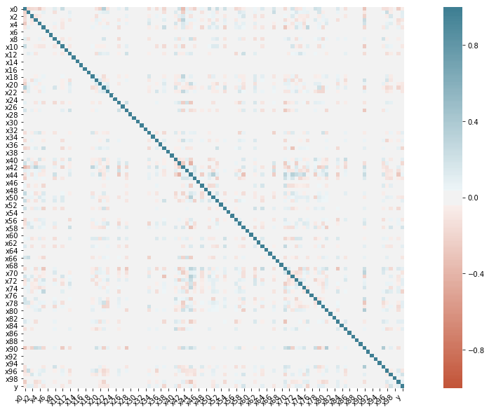

```python
# Plot correlation heatmap to find out if there is any strong correlations among variables (both features and label y)
from matplotlib import pyplot as plt
import seaborn as sns
fig, ax = plt.subplots(figsize = (20,10))
corr = train.corr()
ax = sns.heatmap(corr, vmin = -1, vmax = 1, center=0, cmap=sns.diverging_palette(20,220,n=200), square=True)
ax.set_xticklabels(ax.get_xticklabels(), rotation=45,horizontalalignment='right');
# As there is no dark red or dark blue color in the heatmap
# (except the diagonal with correlation of 1 for a variable to itself),
# the variables (both features and the label y) are not strongly correlated.
```

```python
# Represnt all features by X and label by y in training data
X = train.drop(['y'] ,axis=1)
Y = train['y']

from sklearn.metrics import f1_score,classification_report,accuracy_score,roc_curve,roc_auc_score,confusion_matrix
from sklearn.model_selection import train_test_split
from sklearn import metrics

# Split training data in training and validation samples: 30% validation, 70% training samples
X_train, X_valid, y_train, y_valid = train_test_split(X, Y, test_size=0.30, random_state = 42)

# find out rows and columns of X_train and X_valid
print('Training Data Shape:', X_train.shape)
print('validation data shape: ', X_valid.shape)
```

```
Training Data Shape: (28000, 100)
validation data shape:  (12000, 100)
```

```python
# Standardize the features of trianing/validation/test data (with mean=0 and standard deviation=1) so that
# all of them are uniformly evaluated. Since the range of values of raw data varies widely,
# in some machine learning algorithms, objective functions will not work properly without normalization.
# For example, the majority of classifiers calculate the distance between two points by the Euclidean distance.
# If one of the features has a broad range of values, the distance will be governed by this particular feature.
# Therefore, the range of all features should be normalized so that each feature contributes approximately
# proportionately to the final distance.

from sklearn import preprocessing
X_train = preprocessing.scale(X_train) # scale training data
X_valid = preprocessing.scale(X_valid) # scale validation data
test = preprocessing.scale(test)       # Scale the test data
print(X_train.shape)
print(X_valid.shape)
print(test.shape)
```

```
(28000, 100)
(12000, 100)
(10000, 100)
```

Data visualization (before standardization)

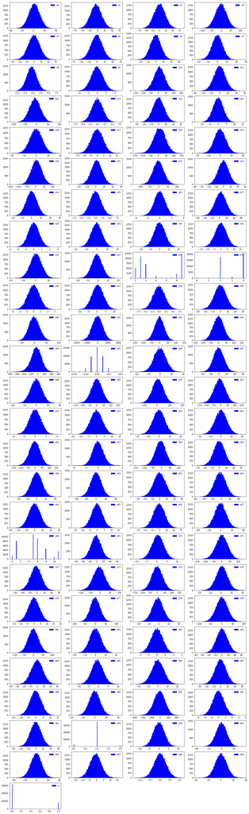

```python
from matplotlib import pyplot as plt

# Define generically how many plots along horizontal (ncols) and vertical (nrows)
ncols=4
nrows = int(np.ceil(len(train.columns)/(1.0*ncols)))
fig, axes = plt.subplots(nrows=nrows, ncols=ncols, figsize = (20,70))

counter=0
for i in range(nrows):
    for j in range(ncols):
        ax = axes[i][j]

        # Plot when we have data
        if counter < len(train.columns):
            ax.hist(train[train.columns[counter]], bins=100, color='blue', label='{}'.format(train.columns[counter]))
            #ax.hist(train[train.columns[counter]], label='{}'.format(train.columns[counter]))
            ax.set_xlabel('')
            ax.set_ylabel('')
            leg=ax.legend(loc='upper right')
            leg.draw_frame(False)

        # Remove axis when we no longer have data
        else:
            ax.set_axis_off()
        counter +=1
plt.show()
plt.show()
```

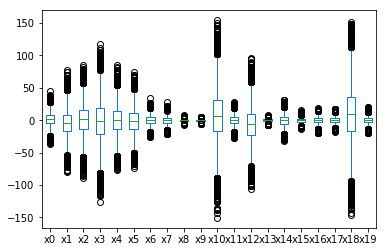

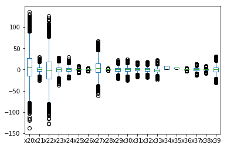

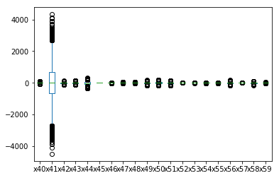

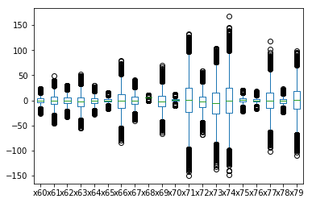

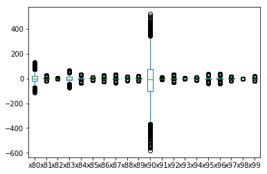

```python
# boxplots show a litte better if there's any outliers.
train.iloc[:,0:20].plot.box()
train.iloc[:,20:40].plot.box()
train.iloc[:,40:60].plot.box()
train.iloc[:,60:80].plot.box()
train.iloc[:,80:100].plot.box()
```

Below is XGBoost model tuning by finding the best parameters.

```python
# Find the best parameters for the XGBoost classification by grid search
# https://www.kaggle.com/tilii7/hyperparameter-grid-search-with-xgboost

from sklearn.model_selection import RandomizedSearchCV, GridSearchCV
from sklearn.model_selection import StratifiedKFold
import xgboost as xgb
from xgboost import XGBClassifier
import datetime
st = datetime.datetime.now() # start time
print("start time: ", st)

# A parameter grid for XGBoost
params = {'learning_rate': [0.05, 0.1, 0.15, 0.2, 0.25, 0.3],
          'n_estimators': [100, 200, 250, 300, 350, 400],
        'min_child_weight': [1, 5, 7, 10],
        'gamma': [0.0, 0.5, 1, 1.5, 2, 5],
        'subsample': [0.5, 0.6,0.7, 0.8, 0.9, 1.0],
        'colsample_bytree': [0.5, 0.6,0.7, 0.8, 0.9, 1.0],
        'max_depth': [6,7,8,9,10,11]
        }

xgb_model = xgb.XGBClassifier(objective='binary:logistic', silent=True, nthread=1)
folds = 5
param_comb = 5
skf = StratifiedKFold(n_splits=folds, shuffle = True, random_state = 1001)
random_search = RandomizedSearchCV(xgb_model, param_distributions=params, n_iter=param_comb,
                                   scoring='roc_auc', n_jobs=4, cv=skf.split(X,Y), verbose=3, random_state=1001 )
random_search.fit(X, Y)

print('\n All results:')
print(random_search.cv_results_)
print('\n Best estimator:')
print(random_search.best_estimator_)
print('\n Best normalized gini score for %d-fold search with %d parameter combinations:' % (folds, param_comb))
print(random_search.best_score_ * 2 - 1)
print('\n Best hyperparameters:')
print(random_search.best_params_)

nd = datetime.datetime.now() # end time of running
print("Code run-time: ", nd-st) # code run time
```

```
start time:  2019-08-26 12:07:29.207252
Fitting 5 folds for each of 5 candidates, totalling 25 fits
```

```
[Parallel(n_jobs=4)]: Using backend LokyBackend with 4 concurrent workers.
[Parallel(n_jobs=4)]: Done  25 out of  25 | elapsed: 25.7min finished
```

```
 All results:
{'mean_fit_time': array([ 92.8086606 , 174.34942603, 280.013029  , 252.36856208,
       341.98049583]), 'std_fit_time': array([ 4.18978755,  1.54885171,  2.98018209,  3.09326898, 44.84855891]), 'mean_score_time': array([0.26619496, 0.38793731, 0.43504701, 0.43462725, 0.45427985]), 'std_score_time': array([0.04703252, 0.02580796, 0.02815124, 0.04573613, 0.09682281]), 'param_subsa…
             mask=[False, False, False, False, False],
       fill_value='?',
            dtype=object), 'param_n_estimators': masked_array(data=[100, 250, 350, 300, 400],
             mask=[False, False, False, False, False],
       fill_value='?',
            dtype=object), 'param_min_child_weight': masked_array(data=[10, 10, 5, 7, 1],
             mask=[False, False, False, False, False],
       fill_value='?',
            dtype=object), 'param_max_depth': masked_array(data=[8, 7, 6, 7, 6],
             mask=[False, False, False, False, False],
       fill_value='?',
            dtype=object), 'param_learning_rate': masked_array(data=[0.2, 0.05, 0.1, 0.2, 0.05],
             mask=[False, False, False, False, False],
       fill_value='?',
            dtype=object), 'param_gamma': masked_array(data=[1.5, 2, 2, 0.0, 0.5],
             mask=[False, False, False, False, False],
       fill_value='?',
            dtype=object), 'param_colsample_bytree': masked_array(data=[0.7, 0.6, 0.8, 0.7, 0.8],
             mask=[False, False, False, False, False],
       fill_value='?',
            dtype=object), 'params': [{'subsample': 0.6, 'n_estimators': 100, 'min_child_weight': 10, 'max_depth': 8, 'learning_rate': 0.2, 'gamma': 1.5, 'colsample_bytree': 0.7}, {'subsample': 0.6, 'n_estimators': 250, 'min_child_weight': 10, 'max_depth': 7, 'learning_rate': 0.05, 'gamma': 2, 'cols…
       4.21752232e-05])}

 Best estimator:
XGBClassifier(base_score=0.5, booster='gbtree', colsample_bylevel=1,
       colsample_bytree=0.7, gamma=0.0, learning_rate=0.2,
       max_delta_step=0, max_depth=7, min_child_weight=7, missing=None,
       n_estimators=300, n_jobs=1, nthread=1, objective='binary:logistic',
       random_state=0, reg_alpha=0, reg_lambda=1, scale_pos_weight=1,
       seed=None, silent=True, subsample=0.9)

 Best normalized gini score for 5-fold search with 5 parameter combinations:
0.975314475620001

 Best hyperparameters:
{'subsample': 0.9, 'n_estimators': 300, 'min_child_weight': 7, 'max_depth': 7, 'learning_rate': 0.2, 'gamma': 0.0, 'colsample_bytree': 0.7}
Code run-time:  0:28:30.790149
```

Best estimator (from above code snippet): XGBClassifier(base_score=0.5, booster='gbtree', colsample_bylevel=1, colsample_bytree=0.7, gamma=0.0, learning_rate=0.2, max_delta_step=0, max_depth=7, min_child_weight=7, missing=None, n_estimators=300, n_jobs=1, nthread=1, objective='binary:logistic', random_state=0, reg_alpha=0, reg_lambda=1, scale_pos_weight=1, seed=None, silent=True, subsample=0.9)

Best hyperparameters: {'subsample': 0.9, 'n_estimators': 300, 'min_child_weight': 7, 'max_depth': 7, 'learning_rate': 0.2, 'gamma': 0.0, 'colsample_bytree': 0.7}

```python
from matplotlib import pyplot as plt
import xgboost as xgb
from xgboost.sklearn import XGBClassifier
# https://www.kaggle.com/gilbar/xgboost-learning-curve

# Use the best estimater obtained in the previous cell code-snippet
xgbooster = xgb.XGBClassifier(base_score=0.5, booster='gbtree', colsample_bylevel=1,
       colsample_bytree=0.7, gamma=0.0, learning_rate=0.2,
       max_delta_step=0, max_depth=7, min_child_weight=7, missing=None,
       n_estimators=300, n_jobs=1, nthread=1, objective='binary:logistic',
       random_state=0, reg_alpha=0, reg_lambda=1, scale_pos_weight=1,
       seed=None, silent=True, subsample=0.9)
scorestrain=[]
scorescv=[]
iterations=[]


for i in range(1000,len(X_train),3000) :
    print(i)
    xgbooster.fit(X_train[:i], y_train[:i], early_stopping_rounds=50, eval_metric="auc",
    eval_set=[(X_valid, y_valid)])
    scorestrain.append(roc_auc_score(y_train[:i], xgbooster.predict_proba(X_train[:i],
                                                                          ntree_limit=xgbooster.best_iteration)[:,1]))
    scorescv.append(roc_auc_score(y_valid,xgbooster.predict_proba(X_valid,ntree_limit=xgbooster.best_iteration)[:,1]))
    iterations.append(i)
#
```

```
1000
Will train until validation_0-auc hasn't improved in 50 rounds.
Stopping. Best iteration:

4000
Will train until validation_0-auc hasn't improved in 50 rounds.
Stopping. Best iteration:

7000
Will train until validation_0-auc hasn't improved in 50 rounds.
10000
Will train until validation_0-auc hasn't improved in 50 rounds.
13000
Will train until validation_0-auc hasn't improved in 50 rounds.
16000
Will train until validation_0-auc hasn't improved in 50 rounds.
19000
Will train until validation_0-auc hasn't improved in 50 rounds.
22000
Will train until validation_0-auc hasn't improved in 50 rounds.
25000
Will train until validation_0-auc hasn't improved in 50 rounds.
```

```
28000
[1000, 4000, 7000, 10000, 13000, 16000, 19000, 22000, 25000]
```

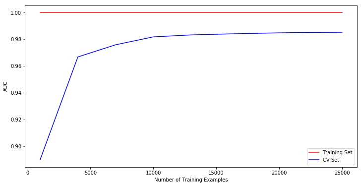

```python
# (continued from above cell)
print(len(X_train))
plt.figure(figsize=(12,6))
plt.plot(iterations,scorestrain,'r')
plt.plot(iterations,scorescv, 'b')
print(iterations)
plt.xlabel('Number of Training Examples')
plt.ylabel('AUC')
plt.legend(['Training Set','CV Set'],loc='lower right')
```

```python
from matplotlib import pyplot as plt
import xgboost as xgb
from xgboost.sklearn import XGBClassifier

# This code will show two sets of plots: logloss and classification error at the end of the output
# after finishing all 300 n_estimators (the number of boosting rounds or the number of trees to fit)
# Use the best estimater obtained in previous cell code-snippet
model = xgb.XGBClassifier(base_score=0.5, booster='gbtree', colsample_bylevel=1,
       colsample_bytree=0.7, gamma=0.0, learning_rate=0.2,
       max_delta_step=0, max_depth=7, min_child_weight=7, missing=None,
       n_estimators=300, n_jobs=1, nthread=1, objective='binary:logistic',
       random_state=0, reg_alpha=0, reg_lambda=1, scale_pos_weight=1,
       seed=None, silent=True, subsample=0.9).fit(X_train, y_train)
eval_set = [(X_train, y_train), (X_valid, y_valid)]
model.fit(X_train, y_train, eval_metric=["error", "logloss"], eval_set=eval_set, verbose=True)
# make predictions for validation data
y_pred = model.predict(X_valid)
predictions = [round(value) for value in y_pred]
# evaluate predictions
accuracy = accuracy_score(y_valid, predictions)
print("Accuracy: %.2f%%" % (accuracy * 100.0))
```

```
Accuracy: 97.42%
```

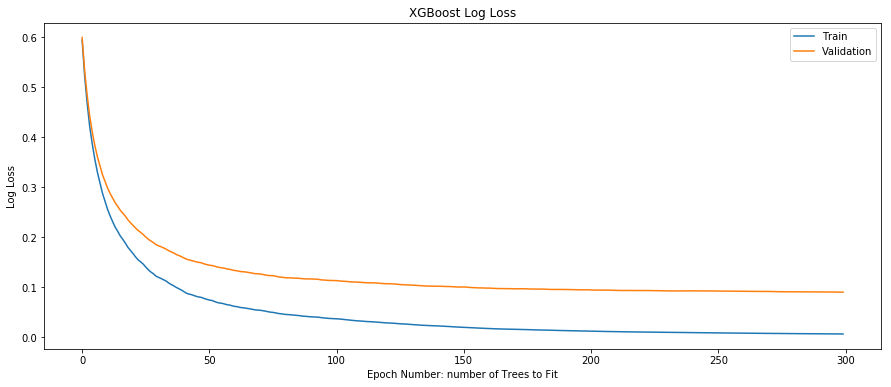

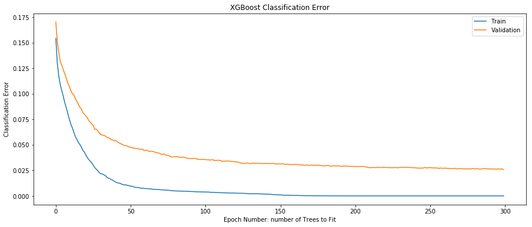

```python
# (continued from above cell)
# retrieve performance metrics
results = model.evals_result()
epochs = len(results['validation_0']['error'])
x_axis = range(0, epochs)
# plot log loss
fig, ax = plt.subplots(figsize=(15,6))
ax.plot(x_axis, results['validation_0']['logloss'], label='Train')
ax.plot(x_axis, results['validation_1']['logloss'], label='Validation')
ax.legend()
plt.ylabel('Log Loss')
plt.xlabel('Epoch Number: number of Trees to Fit')
plt.title('XGBoost Log Loss')
plt.show()
# plot classification error
fig, ax = plt.subplots(figsize=(15,6))
ax.plot(x_axis, results['validation_0']['error'], label='Train')
ax.plot(x_axis, results['validation_1']['error'], label='Validation')
ax.legend()
plt.ylabel('Classification Error')
plt.xlabel('Epoch Number: number of Trees to Fit')
plt.title('XGBoost Classification Error')
plt.show()
```

Eliminating less important features using Recursive Feature Elimination of RFE package of sklearn

```python
import datetime
st = datetime.datetime.now() # start time
print("start time: ", st)

from sklearn.feature_selection import RFE
import xgboost as xgb
from xgboost.sklearn import XGBClassifier

# To find more about the meaning of tuning parameters:
# https://xgboost.readthedocs.io/en/latest//parameter.html
# Use the best estimater obtained in the previous cell code-snippet
xgb_model = xgb.XGBClassifier(base_score=0.5, booster='gbtree', colsample_bylevel=1,
       colsample_bytree=0.7, gamma=0.0, learning_rate=0.2,
       max_delta_step=0, max_depth=7, min_child_weight=7, missing=None,
       n_estimators=300, n_jobs=1, nthread=1, objective='binary:logistic',
       random_state=0, reg_alpha=0, reg_lambda=1, scale_pos_weight=1,
       seed=None, silent=True, subsample=0.9)

rfe = RFE(xgb_model)
rfe = rfe.fit(X_train, y_train)
print(rfe.support_)
print()
print(rfe.ranking_)

nd = datetime.datetime.now() # end time
print("\nCode run-time: ", nd-st)

# Each True and False belong to features starting from x0 to x99 contiguously.
# The features with True are important and the feature with False are not important (which can be dropped).
```

```
start time:  2019-08-26 12:48:36.108117
[ True  True  True  True  True  True False False  True False  True False
  True False False False False False False  True False  True  True False
 False  True False  True False False False False False  True False  True
 False  True False False  True  True False  True  True  True False  True
 False  True  True  True False  True False False  True  True  True False
 False  True False  True False False  True False False  True  True  True
  True  True  True  True False False  True  True  True False False  True
 False  True False False False False  True False False False False  True
  True  True False  True]

[ 1  1  1  1  1  1 45  7  1 10  1 16  1  9 18 40 31 29  5  1  2  1  1 44
 48  1 32  1 37 22 35 12 39  1 51  1 25  1 19 41  1  1  6  1  1  1 27  1
 13  1  1  1 42  1 49 21  1  1  1 36 17  1 30  1 38 15  1 47  3  1  1  1
  1  1  1  1 28  4  1  1  1 14 33  1 26  1 34  8 46 20  1 43 11 50 23  1
  1  1 24  1]

Code run-time:  1:09:34.988718
```

Below is model tuning for Support Vector Classifier.

```python
# Find the best kernel by grid search.

import datetime
st = datetime.datetime.now() # start time of running
print("started at: ",st)


from sklearn.svm import SVC
from sklearn.model_selection import GridSearchCV

# Set the parameters by cross-validation
tuned_parameters = [{'kernel': ['poly'],'C': [1, 10, 100, 1000]},
                    {'kernel': ['rbf'], 'C': [1, 10, 100, 1000]}]

scores = ['precision', 'recall']

for score in scores:
    print("# Tuning hyper-parameters for %s" % score)
    print()

    clf = GridSearchCV(SVC(), tuned_parameters, cv=5, scoring='%s_macro' % score)
    clf.fit(X_train, y_train)

    print("Best parameters set found on development set:")
    print()
    print(clf.best_params_)
    print()
    print("Grid scores on development set:")
    print()
    means = clf.cv_results_['mean_test_score']
    stds = clf.cv_results_['std_test_score']
    for mean, std, params in zip(means, stds, clf.cv_results_['params']):
        print("%0.3f (+/-%0.03f) for %r" % (mean, std * 2, params))
    print()

    print("Detailed classification report:")
    print()
    print("The model is trained on the full development set.")
    print("The scores are computed on the full evaluation set.")
    print()
    y_true, y_pred = y_valid, clf.predict(X_valid)
    print(classification_report(y_true, y_pred))
    print()

nd = datetime.datetime.now() # end time of running
print("Code run-time: ", nd-st)


# Best parameters set found on development set:
# {'C': 100, 'kernel': 'rbf'}
```

```
started at:  2019-08-26 13:58:11.179596
# Tuning hyper-parameters for precision

Best parameters set found on development set:

{'C': 100, 'kernel': 'rbf'}

Grid scores on development set:

0.953 (+/-0.004) for {'C': 1, 'kernel': 'poly'}
0.955 (+/-0.008) for {'C': 10, 'kernel': 'poly'}
0.955 (+/-0.008) for {'C': 100, 'kernel': 'poly'}
0.955 (+/-0.008) for {'C': 1000, 'kernel': 'poly'}
0.986 (+/-0.003) for {'C': 1, 'kernel': 'rbf'}
0.988 (+/-0.003) for {'C': 10, 'kernel': 'rbf'}
0.988 (+/-0.003) for {'C': 100, 'kernel': 'rbf'}
0.988 (+/-0.003) for {'C': 1000, 'kernel': 'rbf'}

Detailed classification report:

The model is trained on the full development set.
The scores are computed on the full evaluation set.

              precision    recall  f1-score   support

           0       0.99      1.00      0.99      9540
           1       0.99      0.95      0.97      2460

   micro avg       0.99      0.99      0.99     12000
   macro avg       0.99      0.98      0.98     12000
weighted avg       0.99      0.99      0.99     12000


# Tuning hyper-parameters for recall

Best parameters set found on development set:

{'C': 100, 'kernel': 'rbf'}

Grid scores on development set:
```

[output cut: 11 more lines]

```

The model is trained on the full development set.
The scores are computed on the full evaluation set.

              precision    recall  f1-score   support

           0       0.99      1.00      0.99      9540
           1       0.99      0.95      0.97      2460

   micro avg       0.99      0.99      0.99     12000
   macro avg       0.99      0.98      0.98     12000
weighted avg       0.99      0.99      0.99     12000


Code run-time:  4:19:31.557089
```